# Subway

Jihyun

7/16/2019

# 날씨에 따른 서울 지하철 2호선 혼잡도 예상

## 1. 데이터 전처리

```r
library(openxlsx)
library(dplyr)
```

### 지하철 데이터를 읽어옵니다.

#### 2018년

```r
# 2018년 데이터
subway_2018_raw <- read.xlsx("subway/subway_2018.xlsx", sheet = 1,startRow = 2, colNames = TRUE)
```

2018년도의 일별 2호선 승차 데이터를 분리해 냅니다.

```r
subway_2018 <- subway_2018_raw %>%
  filter(on_off == '승차' & line == '2호선')
```

num 형태의 date를 date 형태로 변형하고, date 변수를 통해 day를 변수를 만들어 줍니다.

```r
subway_2018$date <- convertToDate(subway_2018$date)# 43101 -> 2018-01-01
subway_2018$day <- weekdays(as.Date(subway_2018$date)) #2018-01-01 -> Monday
```

휴일과 아닌날을 구분하기 위해 2018년의 공휴일 리스트를 가져온 후, holiday 변수에 휴일과 아닌날을 구분해 줍니다.

```r
holiday_2018 <- c('2018-01-01', '2018-02-15', '2018-02-16', '2018-02-17',
            '2018-03-01', '2018-05-05', '2018-05-22', '2018-06-06',
            '2018-06-13', '2018-05-07', '2018-05-06', '2018-05-01',
            '2018-08-15', '2018-09-23', '2018-09-24', '2018-09-26',
            '2018-09-25', '2018-10-03', '2018-10-09', '2018-12-25')

subway_2018$holiday <- ifelse(subway_2018$day %in% c('Saturday', 'Sunday') | subway_2018$date %in% as.Date.character(holiday_2018), 'T', 'F')
```

오전 6시부터 10시, 오후 5시부터 9시까지 출퇴근 시간대로 구분하여 각 날의 출퇴근 인원을 rush_user변수에 담았습니다. 휴일에는 출퇴근 인원이 없다고 가정하여, notrush_user에 전체 인원을 넣었습니다.

```r
rush_user_2018 <- ifelse(subway_2018[,"holiday"] == 'T',0, rowSums(subway_2018[,c(7:10,18:21)]))
notrush_user_2018 <- ifelse(subway_2018[,"holiday"] == 'T',subway_2018[,26], subway_2018[,26]-rush_user_2018)
```

구한 rush_usre와 notrush_user를 subway_2018변수와 합쳐줍니다.

```r
subway_2018 = cbind(subway_2018, rush_user_2018)
subway_2018 = cbind(subway_2018, notrush_user_2018)
head(subway_2018)
```

```
##         date  line station_code       station_name on_off 05.~.06 06.~.07
## 1 2018-01-01 2호선          201               시청   승차      37      57
## 2 2018-01-01 2호선          202         을지로입구   승차     128     116
## 3 2018-01-01 2호선          203          을지로3가   승차      42      79
## 4 2018-01-01 2호선          204          을지로4가   승차      24      41
## 5 2018-01-01 2호선          205 동대문역사문화공원   승차     123     112
## 6 2018-01-01 2호선          206               신당   승차     140     139
##   07.~.08 08.~.09 09.~.10 10.~.11 11.~.12 12.~.13 13.~.14 14.~.15 15.~.16
## 1      77     106     179     342     478     502     448     568     610
## 2     127     205     373     524     827    1116    1184    1468    1722
## 3      98     124     215     542     454     778     539     538     528
## 4      57      83     151     227     342     283     317     274     271
## 5     146     195     361     413     506     638     772     737     964
## 6     144     253     311     400     460     527     607     629     631
##   16.~.17 17.~.18 18.~.19 19.~.20 20.~.21 21.~.22 22.~.23 23.~.24 00.~.01
## 1     698     798     765     630     633     617     392     176       2
## 2    1798    2139    2478    2001    1862    2196    1804     863      13
## 3     545     619     539     427     367     342     237      98       0
## 4     308     296     247     194     139     126      78      37       3
## 5    1103     984     978     865     808     685     616     446       2
## 6     721     635     496     326     276     251     214     114       1
##     sum    day holiday rush_user_2018 notrush_user_2018
## 1  8115 Monday       T              0              8115
## 2 22944 Monday       T              0             22944
## 3  7111 Monday       T              0              7111
## 4  3498 Monday       T              0              3498
## 5 11454 Monday       T              0             11454
## 6  7275 Monday       T              0              7275
```

시간대별로, 지하철 역 별로 나눠진 인원을 일자별로 합쳐줍니다.

```r
subway_2018 = subway_2018 %>%
  group_by(date,holiday,day) %>%
  summarise(rush_user_tot= sum(rush_user_2018), notrush_user_tot = sum(notrush_user_2018))
head(subway_2018)
```

```
## # A tibble: 6 x 5
## # Groups:   date, holiday [6]
##   date       holiday day       rush_user_tot notrush_user_tot
##   <date>     <chr>   <chr>             <dbl>            <dbl>
## 1 2018-01-01 T       Monday                0           704331
## 2 2018-01-02 F       Tuesday          922781           686791
## 3 2018-01-03 F       Wednesday        943062           722416
## 4 2018-01-04 F       Thursday         934506           742750
## 5 2018-01-05 F       Friday           977363           788476
## 6 2018-01-06 T       Saturday              0          1262856
```

앞으로의 분서을 쉽게 하기 위해서 변수명을 수정해 줍니다.

```r
subway_2018 <- rename(subway_2018,
                      rush_user = rush_user_tot,
                      notrush_user = notrush_user_tot)
head(subway_2018)
```

```
## # A tibble: 6 x 5
## # Groups:   date, holiday [6]
##   date       holiday day       rush_user notrush_user
##   <date>     <chr>   <chr>         <dbl>        <dbl>
## 1 2018-01-01 T       Monday            0       704331
## 2 2018-01-02 F       Tuesday      922781       686791
## 3 2018-01-03 F       Wednesday    943062       722416
## 4 2018-01-04 F       Thursday     934506       742750
## 5 2018-01-05 F       Friday       977363       788476
## 6 2018-01-06 T       Saturday          0      1262856
```

#### 2017년

2017년 데이터는 10월달부터 데이터의 날짜 형식이 달라져서 분리해서 전처리 했습니다.

2018년 데이터와 마찬가지로 데이터를 읽어오고, 2호선 승차 데이터만 분리해 냅니다.

```r
subway_2017_raw <- read.xlsx("subway/subway_2017.xlsx", sheet = 1,startRow = 2, colNames = TRUE)
subway_2017 = subway_2017_raw %>%
  filter(on_off == '승차' & line == '2')
```

2017년 1월~9월을 date 형식은 다음과 같습니다.

```r
str(subway_2017[13650,]$date)
```

```
##  chr "2017-09-30"
```

2017년 10월~ 12월의 date 형식은 다음과 같습니다.

```r
str(subway_2017[13651,]$date)
```

```
##  chr "43009"
```

date의 형식이 달라서 2017년의 1월달 ~ 9월달, 10월달~ 12월달을 분리하였습니다.

```r
row <- nrow(subway_2017)
subway_2017_1to9 <- subway_2017[0:13650,]
subway_2017_10to12 <- subway_2017[13651:row,]
```

두 데이터 프레임에 date와 day 변수를 만들어 줍니다.

```r
subway_2017_1to9$day = weekdays(as.Date(subway_2017_1to9$date))
subway_2017_1to9$date = as.Date.character(subway_2017_1to9$date)
head(subway_2017_1to9)
```

```
##         date line subway_code        subway_name on_off 05~06 06~07 07~08
## 1 2017-01-01    2         201               시청   승차    48    57    70
## 2 2017-01-01    2         202         을지로입구   승차   114   156   110
## 3 2017-01-01    2         203          을지로3가   승차    46    74    96
## 4 2017-01-01    2         204          을지로4가   승차    25    41    46
## 5 2017-01-01    2         205 동대문역사문화공원   승차   135   103    97
## 6 2017-01-01    2         206               신당   승차   103   143   162
##   08~09 09~10 10~11 11~12 12~13 13~14 14~15 15~16 16~17 17~18 18~19 19~20
## 1   110   161   250   391   452   499   580   650   733   676   640   585
## 2   164   420   571   880  1102  1346  1626  1796  2095  2356  2572  2073
## 3   275   248   459   709   646   726   708   752   851   761   563   448
## 4    61   141   240   246   319   240   256   274   260   272   258   179
## 5   251   315   465   660   651   801   782  1036  1137  1144   953   921
## 6   337   363   505   498   570   784   705   783   791   735   546   411
##   20~21 21~22 22~23 23~24 00.~.01   sum    day
## 1   498   472   370   214       0  7456 Sunday
## 2  2006  2443  1903   832       1 24566 Sunday
## 3   345   295   283    86       0  8371 Sunday
## 4   143   101   111    35       0  3248 Sunday
## 5   903   788   730   415       0 12287 Sunday
## 6   275   250   223    88       0  8272 Sunday
```

```r
subway_2017_10to12$date = as.Date(convertToDate(subway_2017_10to12$date))
subway_2017_10to12$day = weekdays(as.Date(subway_2017_10to12$date))
head(subway_2017_10to12)
```

```
##             date line subway_code        subway_name on_off 05~06 06~07
## 13651 2017-10-01    2         201               시청   승차    34    45
## 13652 2017-10-01    2         202         을지로입구   승차    99    77
## 13653 2017-10-01    2         203          을지로3가   승차    15    62
## 13654 2017-10-01    2         204          을지로4가   승차    29    36
## 13655 2017-10-01    2         205 동대문역사문화공원   승차   120    81
## 13656 2017-10-01    2         206               신당   승차   141   187
##       07~08 08~09 09~10 10~11 11~12 12~13 13~14 14~15 15~16 16~17 17~18
## 13651    55   127   138   268   392   519   591   707   691   716   754
## 13652    98   280   372   548   798  1132  1371  1670  2025  2236  2499
## 13653    78   287   308   469   530   762   648   785   707   756   660
## 13654    51   128   175   248   280   348   354   417   335   360   315
## 13655   120   261   369   467   545   711   792   831  1122  1094  1160
## 13656   202   393   585   595   657   794   877   726   801   746   757
##       18~19 19~20 20~21 21~22 22~23 23~24 00.~.01   sum    day
## 13651   782   612   604   409   295    79       0  7818 Sunday
## 13652  2984  2573  3316  2611  1577   692       0 26958 Sunday
## 13653   595   427   332   311   241   103       0  8076 Sunday
## 13654   348   237   183   169    98    22       0  4133 Sunday
## 13655   985  1024   903   922   788   584       0 12879 Sunday
## 13656   642   444   401   408   225   127       0  9708 Sunday
```

형식이 같아진 두 데이터를 합쳐줍니다.

```r
subway_2017 = rbind(subway_2017_1to9, subway_2017_10to12)
head(subway_2017)
```

```
##         date line subway_code        subway_name on_off 05~06 06~07 07~08
## 1 2017-01-01    2         201               시청   승차    48    57    70
## 2 2017-01-01    2         202         을지로입구   승차   114   156   110
## 3 2017-01-01    2         203          을지로3가   승차    46    74    96
## 4 2017-01-01    2         204          을지로4가   승차    25    41    46
## 5 2017-01-01    2         205 동대문역사문화공원   승차   135   103    97
## 6 2017-01-01    2         206               신당   승차   103   143   162
##   08~09 09~10 10~11 11~12 12~13 13~14 14~15 15~16 16~17 17~18 18~19 19~20
## 1   110   161   250   391   452   499   580   650   733   676   640   585
## 2   164   420   571   880  1102  1346  1626  1796  2095  2356  2572  2073
## 3   275   248   459   709   646   726   708   752   851   761   563   448
## 4    61   141   240   246   319   240   256   274   260   272   258   179
## 5   251   315   465   660   651   801   782  1036  1137  1144   953   921
## 6   337   363   505   498   570   784   705   783   791   735   546   411
##   20~21 21~22 22~23 23~24 00.~.01   sum    day
## 1   498   472   370   214       0  7456 Sunday
## 2  2006  2443  1903   832       1 24566 Sunday
## 3   345   295   283    86       0  8371 Sunday
## 4   143   101   111    35       0  3248 Sunday
## 5   903   788   730   415       0 12287 Sunday
## 6   275   250   223    88       0  8272 Sunday
```

```r
tail(subway_2017)
```

```
##             date line subway_code      subway_name on_off 05~06 06~07
## 18245 2017-12-31    2         245             신답   승차    19    19
## 18246 2017-12-31    2         246           신설동   승차    31    39
## 18247 2017-12-31    2         247           도림천   승차     5    14
## 18248 2017-12-31    2         248         양천구청   승차    77    90
## 18249 2017-12-31    2         249       신정네거리   승차   101   124
## 18250 2017-12-31    2         250 용두(동대문구청)   승차    17    22
##       07~08 08~09 09~10 10~11 11~12 12~13 13~14 14~15 15~16 16~17 17~18
## 18245    30    48    58    58    65    56    66    43    71    64    39
## 18246    30    43   109   151   182   260   348   426   574   544   465
## 18247    18    26    44    33    26    41    40    35    23    27    36
## 18248   111   206   324   328   306   338   316   290   258   263   221
## 18249   190   351   510   487   490   499   484   442   454   400   330
## 18250    32    52    70    63    91   113   115   136   111   137   118
##       18~19 19~20 20~21 21~22 22~23 23~24 00.~.01  sum    day
## 18245    21    22    27    17    18    15      18  774 Sunday
## 18246   538   205   112   139   104    47      21 4368 Sunday
## 18247    25    26    12    17    10    10       5  473 Sunday
## 18248   176   116   125   121   129    32      23 3850 Sunday
## 18249   296   236   185   217   215    81      32 6124 Sunday
## 18250    90    81    53    49    57    38      15 1460 Sunday
```

holiday 변수에 휴일과 휴일이 아닌 날로 구분하여 넣어줍니다.

```r
holiday_2017 = c('2017-01-01', '2017-01-27', '2017-01-28','2017-01-29','2017-01-30',
                 '2017-03-01',
                 '2017-05-01','2017-05-03','2017-05-05','2017-10-02',
                 '2017-06-06',
                 '2017-08-15','2017-05-09',
                 '2017-10-03', '2017-10-04', '2017-10-05', '2017-10-06', '2017-10-09',
                '2017-12-25')

subway_2017$holiday = ifelse(subway_2017$day %in% c('Saturday', 'Sunday') | subway_2017$date %in% as.Date.character(holiday_2017), 'T', 'F')
head(subway_2017)
```

```
##         date line subway_code        subway_name on_off 05~06 06~07 07~08
## 1 2017-01-01    2         201               시청   승차    48    57    70
## 2 2017-01-01    2         202         을지로입구   승차   114   156   110
## 3 2017-01-01    2         203          을지로3가   승차    46    74    96
## 4 2017-01-01    2         204          을지로4가   승차    25    41    46
## 5 2017-01-01    2         205 동대문역사문화공원   승차   135   103    97
## 6 2017-01-01    2         206               신당   승차   103   143   162
##   08~09 09~10 10~11 11~12 12~13 13~14 14~15 15~16 16~17 17~18 18~19 19~20
## 1   110   161   250   391   452   499   580   650   733   676   640   585
## 2   164   420   571   880  1102  1346  1626  1796  2095  2356  2572  2073
## 3   275   248   459   709   646   726   708   752   851   761   563   448
## 4    61   141   240   246   319   240   256   274   260   272   258   179
## 5   251   315   465   660   651   801   782  1036  1137  1144   953   921
## 6   337   363   505   498   570   784   705   783   791   735   546   411
##   20~21 21~22 22~23 23~24 00.~.01   sum    day holiday
## 1   498   472   370   214       0  7456 Sunday       T
## 2  2006  2443  1903   832       1 24566 Sunday       T
## 3   345   295   283    86       0  8371 Sunday       T
## 4   143   101   111    35       0  3248 Sunday       T
## 5   903   788   730   415       0 12287 Sunday       T
## 6   275   250   223    88       0  8272 Sunday       T
```

출퇴근 시간과, 아닌 시간을 분리해서 인원수를 구했습니다. 출퇴근 시간은 6시부터 10시, 5시부터 9시

```r
rush_user_2017 <- ifelse(subway_2017[,28] == 'T',0, rowSums(subway_2017[,c(7:10,18:21)]))
notrush_user_2017 <- ifelse(subway_2017[,28] == 'T',subway_2017[,26], subway_2017[,26]-rush_user_2017)
```

원래의 subwya_2017 변수에 rush_user_2017 과 notrush_user_2017을 합쳐줍니다.

```r
subway_2017 = cbind(subway_2017, rush_user_2017)
subway_2017 = cbind(subway_2017, notrush_user_2017)
head(subway_2017)
```

```
##         date line subway_code        subway_name on_off 05~06 06~07 07~08
## 1 2017-01-01    2         201               시청   승차    48    57    70
## 2 2017-01-01    2         202         을지로입구   승차   114   156   110
## 3 2017-01-01    2         203          을지로3가   승차    46    74    96
## 4 2017-01-01    2         204          을지로4가   승차    25    41    46
## 5 2017-01-01    2         205 동대문역사문화공원   승차   135   103    97
## 6 2017-01-01    2         206               신당   승차   103   143   162
##   08~09 09~10 10~11 11~12 12~13 13~14 14~15 15~16 16~17 17~18 18~19 19~20
## 1   110   161   250   391   452   499   580   650   733   676   640   585
## 2   164   420   571   880  1102  1346  1626  1796  2095  2356  2572  2073
## 3   275   248   459   709   646   726   708   752   851   761   563   448
## 4    61   141   240   246   319   240   256   274   260   272   258   179
## 5   251   315   465   660   651   801   782  1036  1137  1144   953   921
## 6   337   363   505   498   570   784   705   783   791   735   546   411
##   20~21 21~22 22~23 23~24 00.~.01   sum    day holiday rush_user_2017
## 1   498   472   370   214       0  7456 Sunday       T              0
## 2  2006  2443  1903   832       1 24566 Sunday       T              0
## 3   345   295   283    86       0  8371 Sunday       T              0
## 4   143   101   111    35       0  3248 Sunday       T              0
## 5   903   788   730   415       0 12287 Sunday       T              0
## 6   275   250   223    88       0  8272 Sunday       T              0
##   notrush_user_2017
## 1              7456
## 2             24566
## 3              8371
## 4              3248
## 5             12287
## 6              8272
```

역별, 시간별로 나눠진 데이터를 일자별로 합쳐줍니다.

```r
subway_2017 = subway_2017 %>%
  group_by(date,holiday,day) %>%
  summarise(rush_user_tot= sum(rush_user_2017), notrush_user_tot = sum(notrush_user_2017))
head(subway_2017)
```

```
## # A tibble: 6 x 5
## # Groups:   date, holiday [6]
##   date       holiday day       rush_user_tot notrush_user_tot
##   <date>     <chr>   <chr>             <dbl>            <dbl>
## 1 2017-01-01 T       Sunday                0           739831
## 2 2017-01-02 F       Monday           901914           676281
## 3 2017-01-03 F       Tuesday          935820           721445
## 4 2017-01-04 F       Wednesday        946006           747858
## 5 2017-01-05 F       Thursday         940673           764994
## 6 2017-01-06 F       Friday           983864           807237
```

변수의 이름을 변경시켜 줍니다.

```r
subway_2017 <- rename(subway_2017,
                      rush_user = rush_user_tot,
                      notrush_user = notrush_user_tot)
head(subway_2017)
```

```
## # A tibble: 6 x 5
## # Groups:   date, holiday [6]
##   date       holiday day       rush_user notrush_user
##   <date>     <chr>   <chr>         <dbl>        <dbl>
## 1 2017-01-01 T       Sunday            0       739831
## 2 2017-01-02 F       Monday       901914       676281
## 3 2017-01-03 F       Tuesday      935820       721445
## 4 2017-01-04 F       Wednesday    946006       747858
## 5 2017-01-05 F       Thursday     940673       764994
## 6 2017-01-06 F       Friday       983864       807237
```

위에서 나눠서 전처리한 2017, 2018 데이터를 하나로 합쳐줍니다.

```r
subway_rush <- rbind(subway_2017,subway_2018)
head(subway_rush)
```

```
## # A tibble: 6 x 5
## # Groups:   date, holiday [6]
##   date       holiday day       rush_user notrush_user
##   <date>     <chr>   <chr>         <dbl>        <dbl>
## 1 2017-01-01 T       Sunday            0       739831
## 2 2017-01-02 F       Monday       901914       676281
## 3 2017-01-03 F       Tuesday      935820       721445
## 4 2017-01-04 F       Wednesday    946006       747858
## 5 2017-01-05 F       Thursday     940673       764994
## 6 2017-01-06 F       Friday       983864       807237
```

합친 데이터에서 평균 rush_user, notrush_user의 평균 탑승객 수를 구합니다. 평일 2호선, 출퇴근 시간에 배차된 지하철 수는 266대, 출퇴근 시간이 아닐 때는 221대가 배차되어 있습니다. 토요일 : 2호선의 배차 차량은 총 440대, 일요일의 배차차량은 389대가 배차되어 있습입니다.

먼저 평일의 평균 승객 수 입니다.

```r
notholiday <-subway_rush %>%
  filter(holiday == 'F') %>%
  mutate(mean_rush_user = round((rush_user)/266)) %>%
  mutate(mean_notrush_user = round(((notrush_user)/221)) )


head(notholiday)
```

```
## # A tibble: 6 x 7
## # Groups:   date, holiday [6]
##   date       holiday day   rush_user notrush_user mean_rush_user
##   <date>     <chr>   <chr>     <dbl>        <dbl>          <dbl>
## 1 2017-01-02 F       Mond…    901914       676281           3391
## 2 2017-01-03 F       Tues…    935820       721445           3518
## 3 2017-01-04 F       Wedn…    946006       747858           3556
## 4 2017-01-05 F       Thur…    940673       764994           3536
## 5 2017-01-06 F       Frid…    983864       807237           3699
## 6 2017-01-09 F       Mond…    943555       732090           3547
## # … with 1 more variable: mean_notrush_user <dbl>
```

토요일이면서 공휴일이 아닌날의 평균 승객수입니다. 토요일과 공휴일의 rush user는 0으로 가정하였으므로 mean_rush_user 또한 0 입니다.

```r
saturday <- subway_rush %>%
  filter(day == 'Saturday' & !(date %in% (holiday_2018)) & !(date %in% (holiday_2017))) %>%
  mutate(mean_rush_user = round((rush_user)/1)) %>%
  mutate(mean_notrush_user = round((notrush_user)/440))
head(saturday)
```

```
## # A tibble: 6 x 7
## # Groups:   date, holiday [6]
##   date       holiday day   rush_user notrush_user mean_rush_user
##   <date>     <chr>   <chr>     <dbl>        <dbl>          <dbl>
## 1 2017-01-07 T       Satu…         0      1400875              0
## 2 2017-01-14 T       Satu…         0      1293646              0
## 3 2017-01-21 T       Satu…         0      1359534              0
## 4 2017-01-28 T       Satu…         0       451155              0
## 5 2017-02-04 T       Satu…         0      1354431              0
## 6 2017-02-11 T       Satu…         0      1381691              0
## # … with 1 more variable: mean_notrush_user <dbl>
```

공휴일의 평균 승객 수 입니다.

```r
redday <- subway_rush %>%
  filter(day == 'Sunday' | (date %in% (holiday_2018))| (date %in% (holiday_2017))) %>%
  mutate(mean_rush_user = round((rush_user)/1)) %>%
  mutate(mean_notrush_user = round((notrush_user)/389) )
head(redday)
```

```
## # A tibble: 6 x 7
## # Groups:   date, holiday [6]
##   date       holiday day   rush_user notrush_user mean_rush_user
##   <date>     <chr>   <chr>     <dbl>        <dbl>          <dbl>
## 1 2017-01-01 T       Sund…         0       739831              0
## 2 2017-01-08 T       Sund…         0       942083              0
## 3 2017-01-15 T       Sund…         0       896018              0
## 4 2017-01-22 T       Sund…         0       933085              0
## 5 2017-01-29 T       Sund…         0       667958              0
## 6 2017-02-05 T       Sund…         0       906935              0
## # … with 1 more variable: mean_notrush_user <dbl>
```

평균 승객수가 추가된 세개의 데이터를 다시 합쳐줍니다.

```r
subway_rush <- rbind(notholiday,saturday,redday)
```

### 날씨 데이터를 읽어와서 지하철 데이터에 일별로 합쳐줍니다.

1. 비 데이터

```r
rain <- read.csv('rain/rain.csv', header = T)
rain <- rain[,-1]# 지역코드 삭제
rain$date <- as.Date(rain$date)
rain_simple <- rain[,c(1,4)] # date, 일 강수량만 사용
subway_rush <- merge(x = subway_rush, y = rain_simple, by ='date', all.x = TRUE)
# 비 안온날 데이터 넣어주기
subway_rush$rain <- ifelse(is.na(subway_rush$rain), 0, subway_rush$rain)
```

1. 눈 데이터를 합쳐 주었습니다.

```r
snow <- read.csv('snow/snow.csv', header = T)

snow <- snow[,-1]
snow$date <- as.Date(snow$date)
subway_rush <- merge(x = subway_rush, y = snow, by ='date', all.x = TRUE)
# 눈 안온날 데이터 넣어주기
subway_rush$snow <- ifelse(is.na(subway_rush$snow), 0, subway_rush$snow)
subway_rush$newsnow <- ifelse(is.na(subway_rush$newsnow), 0, subway_rush$newsnow)
```

2. 기온 데이터를 합쳐 주었습니다.

```r
temperature <- read.csv('temperature/temperature.csv', header = T)

temperature <- temperature[,-1]
temperature$date <- as.Date(temperature$date)
subway_rush <- merge(x = subway_rush, y = temperature, by ='date', all.x = TRUE)
```

3. 습도 데이터를 합쳐 주었습니다.

```r
humid <- read.csv('humid/humid.csv', header = T)

humid <- humid[,-1]
humid$date <- as.Date(humid$date)
subway_rush <- merge(x = subway_rush, y = humid, by ='date', all.x = TRUE)
```

4. 바람 데이터를 합쳐 주었습니다.

```r
wind <- read.csv('wind/wind.csv', header = T, stringsAsFactors = F)

wind <- wind[,-1]

wind$date <- as.Date(wind$date)
subway_rush <- merge(x = subway_rush, y = wind, by ='date', all.x = TRUE)
which(is.na(subway_rush$wind))
```

```
## integer(0)
```

```r
View(subway_rush)
```

혼잡도 레벨을 만들어 줍니다.(뉴스참고)

level 구분 1 : 800 2 : 1600 3 : 2000 4 : 2400 5 : 2800 6 : 3200

#### 바쁜 시간대의 busy leve변수를 만들어 넣었습니다.

```r
subway_rush$rush_busylevel <- as.factor(ifelse(subway_rush$mean_rush_user<800, 1,
                              ifelse(subway_rush$mean_rush_user<1600,2,
                                     ifelse(subway_rush$mean_rush_user<2000,3,
                                            ifelse(subway_rush$mean_rush_user<2400,4,
                                                   ifelse(subway_rush$mean_rush_user<2800,5,
                                                          ifelse(subway_rush$mean_rush_user<3200,6,7)))))))
head(subway_rush$rush_busylevel)
```

```
## [1] 1 7 7 7 7 7
## Levels: 1 6 7
```

바쁘지 않은 시간대의 busy leve변수를 만들어 넣었습니다.

```r
subway_rush$notrush_busylevel <- as.factor(ifelse(subway_rush$mean_notrush_user<800, 1,
                                 ifelse(subway_rush$mean_notrush_user<1600,2,
                                        ifelse(subway_rush$mean_notrush_user<2000,3,
                                               ifelse(subway_rush$mean_notrush_user<2400,4,
                                                      ifelse(subway_rush$mean_notrush_user<2800,5,
                                                             ifelse(subway_rush$mean_rush_user<3200,6,7)))))))
head(subway_rush$notrush_busylevel)
```

```
## [1] 3 7 7 7 7 7
## Levels: 2 3 4 5 6 7
```

#### 휴일에는 출퇴근 하는 사람이 없다고 가정하였으므로, 휴일, 출퇴근 시간 혼잡도 레벨을 0으로 두었습니다.

```r
subway_rush$rush_busylevel <- ifelse(subway_rush$holiday == 'T', 0, subway_rush$rush_busylevel)
head(subway_rush)
```

```
##         date holiday       day rush_user notrush_user mean_rush_user
## 1 2017-01-01       T    Sunday         0       739831              0
## 2 2017-01-02       F    Monday    901914       676281           3391
## 3 2017-01-03       F   Tuesday    935820       721445           3518
## 4 2017-01-04       F Wednesday    946006       747858           3556
## 5 2017-01-05       F  Thursday    940673       764994           3536
## 6 2017-01-06       F    Friday    983864       807237           3699
##   mean_notrush_user rain newsnow snow meantemp lowtemp hightemp humid wind
## 1              1902  0.0       0    0      2.7    -1.6      6.9  75.9  1.5
## 2              3060  0.3       0    0      5.0     1.8      9.2  77.8  2.1
## 3              3264  0.0       0    0      2.0    -2.3      7.7  61.8  1.8
## 4              3384  0.0       0    0      3.9     1.0      8.9  55.0  1.7
## 5              3462  0.0       0    0      3.8    -0.1      7.3  52.3  3.1
## 6              3653  0.0       0    0      5.4     2.5     11.4  58.5  2.4
##   rush_busylevel notrush_busylevel
## 1              0                 3
## 2              3                 7
## 3              3                 7
## 4              3                 7
## 5              3                 7
## 6              3                 7
```

```r
subway_rush <- subway_rush  %>%
  filter( !(date %in% (holiday_2018)) & !(date %in% (holiday_2017)))
```

#### knn 분석을 위해 휴일과, 휴일이 아닌 날로 나누었습니다.

```r
notholiday <- subway_rush %>%
  filter(holiday=='F')

holiday <- subway_rush %>%
  filter(holiday=='T')

head(holiday)
```

```
##         date holiday      day rush_user notrush_user mean_rush_user
## 1 2017-01-01       T   Sunday         0       739831              0
## 2 2017-01-07       T Saturday         0      1400875              0
## 3 2017-01-08       T   Sunday         0       942083              0
## 4 2017-01-14       T Saturday         0      1293646              0
## 5 2017-01-15       T   Sunday         0       896018              0
## 6 2017-01-21       T Saturday         0      1359534              0
##   mean_notrush_user rain newsnow snow meantemp lowtemp hightemp humid wind
## 1              1902  0.0     0.0  0.0      2.7    -1.6      6.9  75.9  1.5
## 2              3184  0.0     0.0  0.0      4.6     0.0     10.5  64.9  1.4
## 3              2422  0.0     0.0  0.0      6.5     4.0     10.9  61.4  2.6
## 4              2940  0.0     0.0  0.0     -8.4   -10.5     -5.4  33.3  3.8
## 5              2303  0.0     0.0  0.0     -6.6   -11.5     -0.9  35.3  2.3
## 6              3090  2.1     3.2  5.7     -5.2   -10.0     -0.9  78.1  1.6
##   rush_busylevel notrush_busylevel
## 1              0                 3
## 2              0                 6
## 3              0                 5
## 4              0                 6
## 5              0                 4
## 6              0                 6
```

#### 위에서 나눈 레벨에 따라 레벨 변수를 추가하였습니다.

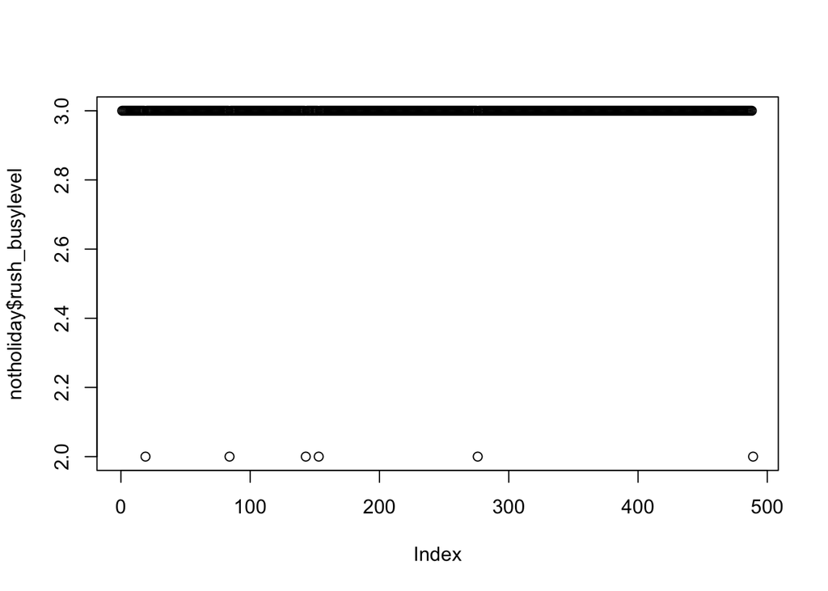

```r
plot(notholiday$rush_busylevel)# 평일 출퇴근 시간의 혼잡도 구간 분포
```

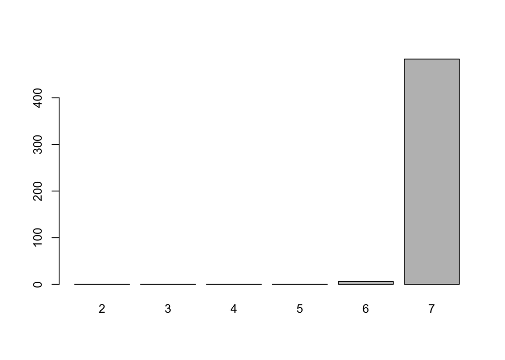

```r
plot(notholiday$notrush_busylevel)# 평일 출퇴근 시간이 아닌때의 구간 혼잡도 분포
```

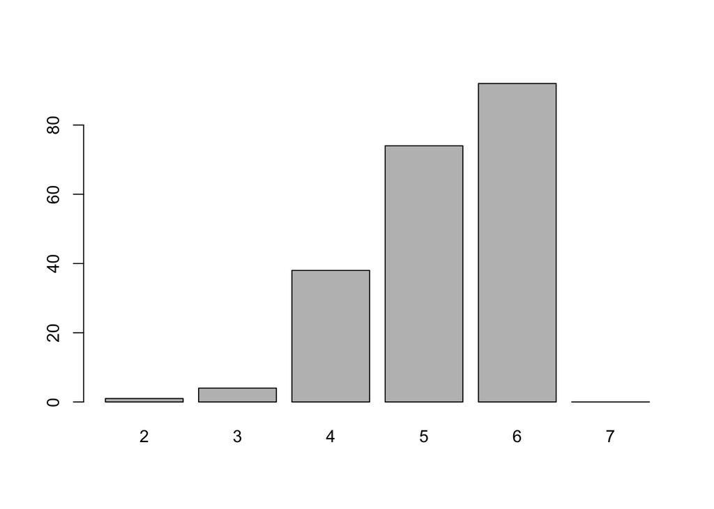

```r
plot(holiday$notrush_busylevel)#휴일의 혼잡도 구간 분포
```